# CW 1

## Task 1

## 1.1 Cleaning Data

### 1.1.1

*In the file climbing_statistics.csv, find the rows where both the date and route are identical, and write commands that aggregate their information as follows: (i) obtain the total number of Attempts and Successes for the same route and date; (ii) compute the percentage of successful attempts to summit for the same route and date. Note: In most datasets, there will be faulty or incomplete data. If there are any rows with inconsistent data based on your computations above, eliminate them from your data set.*

First and foremost, we load the data as a dataframe, using pandas. To get a feel for the set, use the head method to see the first 5 datapoints.

```python
import pandas as pd
import numpy as np

c_data = pd.read_csv("climbing_statistics.csv")
c_data.head()
```

|  | Date | Route | Attempted | Succeeded | Success Percentage |
| --- | --- | --- | --- | --- | --- |
| 0 | 11/27/2015 | Disappointment Cleaver | 2 | 0 | 0.0 |
| 1 | 11/21/2015 | Disappointment Cleaver | 3 | 0 | 0.0 |
| 2 | 10/15/2015 | Disappointment Cleaver | 2 | 0 | 0.0 |
| 3 | 10/13/2015 | Little Tahoma | 8 | 0 | 0.0 |
| 4 | 10/9/2015 | Disappointment Cleaver | 2 | 0 | 0.0 |

There are a few things that need to be done to clean up the data:

- We can find entries that have the same date and routes and we need to aggregate those into single rows. For example, Disappointment Cleaver on 9/9/2015
- Some entries have more successes than attempts (ie. Success Percentages > 1). We'll remove these rows as the information is faulty
- Some of the recorded data is for unknown routes. We'll remove these as they're incomplete.
- Some variations on the spelling (Fuhrer's Finger vs. Fuhrers Finger). We'll make sure the spelling is consistent throughout.

Below, find examples of the things that need to be fixed.

```python
c_data[(c_data["Route"] == "Disappointment Cleaver") & (c_data["Date"] == "9/9/2015")]
```

|  | Date | Route | Attempted | Succeeded | Success Percentage |
| --- | --- | --- | --- | --- | --- |
| 70 | 9/9/2015 | Disappointment Cleaver | 2 | 2 | 1.000000 |
| 71 | 9/9/2015 | Disappointment Cleaver | 2 | 0 | 0.000000 |
| 72 | 9/9/2015 | Disappointment Cleaver | 12 | 10 | 0.833333 |

```python
c_data[(c_data["Success Percentage"] > 1)]
```

|  | Date | Route | Attempted | Succeeded | Success Percentage |
| --- | --- | --- | --- | --- | --- |
| 133 | 8/26/2015 | Disappointment Cleaver | 3 | 4 | 1.333333 |
| 191 | 8/21/2015 | Disappointment Cleaver | 1 | 2 | 2.000000 |
| 507 | 7/27/2015 | Emmons-Winthrop | 3 | 4 | 1.333333 |
| 589 | 7/20/2015 | Disappointment Cleaver | 5 | 71 | 14.200000 |
| 1156 | 6/23/2015 | Disappointment Cleaver | 2 | 5 | 2.500000 |
| 1399 | 6/12/2015 | Disappointment Cleaver | 10 | 11 | 1.100000 |
| 2709 | 7/24/2014 | Disappointment Cleaver | 7 | 8 | 1.142857 |
| 2970 | 7/11/2014 | Kautz Glacier | 11 | 12 | 1.090909 |
| 3010 | 7/10/2014 | Disappointment Cleaver | 3 | 4 | 1.333333 |
| 3196 | 7/3/2014 | Disappointment Cleaver | 1 | 2 | 2.000000 |

```python
c_data.Route.unique()
```

```
array(['Disappointment Cleaver', 'Little Tahoma', 'Kautz Glacier',
       'Emmons-Winthrop', 'glacier only - no summit attempt',
       'Fuhrers Finger', 'Success Cleaver', 'Liberty RIngraham Directge',
       'Kautz Cleaver', 'Tahoma Glacier', 'Ptarmigan RIngraham Directge',
       'Mowich Face', 'Ingraham Direct', 'Sunset RIngraham Directge',
       'Curtis RIngraham Directge', 'Tahoma Cleaver', 'Gibralter Ledges',
       'Nisqually Glacier', 'Wilson Headwall', 'Gibralter Chute',
       "Fuhrer's Finger", 'Unknown', 'Edmonds HW', 'Sunset Amphitheater',
       'Kautz Headwall', 'Liberty Wall'], dtype=object)
```

We'll remove all inconsistent data, starting with removing any row with more successes than attempts. We'll then combine **Fuhrer's Finger** with **Fuhrers Finger**, and finally remove any **Unknown** route. One of the possible routes is **glacier only - no summit attempt**. I leave this is because although there is no summit attempt, if they successfully climb the glacier, and that is what they came to do, it should count as successful in its own category.

We can now aggregate all the entries that have the same date and route. Pandas allows us to use group rows based on a set of columns using the groupby aggregator. We can then immediately sum all the columns not used in the grouping, keeping in mind we're going to have to recalculate the success percentages. This is an easy manipulation, and is done below.

As a quick check, we look at the output for the Disappointment Cleaver on 9/9/2015 grouping and see it matches the sums of the previous three rows.

```python
c_data = c_data[c_data["Success Percentage"] <= 1]
c_data.loc[c_data.Route == "Fuhrers Finger", "Route"] = "Fuhrer's Finger"
c_data = c_data[c_data["Route"] != "Unknown"]

c_data = c_data.groupby(["Date", "Route"]).sum().reset_index()
c_data["Success Percentage"] = c_data["Succeeded"]/c_data["Attempted"]
c_data[(c_data["Route"] == "Disappointment Cleaver") & (c_data["Date"] == "9/9/2015")]
```

|  | Date | Route | Attempted | Succeeded | Success Percentage |
| --- | --- | --- | --- | --- | --- |
| 991 | 9/9/2015 | Disappointment Cleaver | 16 | 12 | 0.75 |

### 1.1.2

*In the file Rainier_Weather.csv, delete all columns that do not contain any information about weather conditions on the given date.*

Similarly to the climbing data, we first have a look at the data set. Quickly, we notice that there are 0 entries for the AVG daily wind speed, and looking further into the dataset find some for other columns as well. We also see that the column **Battery Voltage AVG** seems a bit out of place...

```python
w_data = pd.read_csv("Rainier_Weather.csv")
w_data.head()
```

|  | Date | Battery Voltage AVG | Temperature AVG | Relative Humidity AVG | Wind Speed Daily AVG | Wind Direction AVG | Solar Radiation AVG |
| --- | --- | --- | --- | --- | --- | --- | --- |
| 0 | 12/31/2015 | 13.845000 | 19.062917 | 21.870833 | 21.977792 | 62.325833 | 84.915292 |
| 1 | 12/30/2015 | 13.822917 | 14.631208 | 18.493833 | 3.540542 | 121.505417 | 86.192833 |
| 2 | 12/29/2015 | 13.834583 | 6.614292 | 34.072917 | 0.000000 | 130.291667 | 85.100917 |
| 3 | 12/28/2015 | 13.710417 | 8.687042 | 70.557917 | 0.000000 | 164.683750 | 86.241250 |
| 4 | 12/27/2015 | 13.362500 | 14.140417 | 95.754167 | 0.000000 | 268.479167 | 31.090708 |

As such, we remove any rows with 0s in them. This is because it doesn't seem realistic and implies an error. Further, any incomplete information will mess with the results. We also remove the **Battery voltage AVG** column. To remove the rows including 0s, we check that every value of a row is non-zero, and keep only those that satisfy that condition.

```python
w_data = w_data.drop(columns="Battery Voltage AVG")
#Create a boolean dataframe, and check that for a row, all the values are not equal to 0...
w_data = w_data[(w_data[w_data.columns] != 0).all(axis=1)]
w_data.head()
```

|  | Date | Temperature AVG | Relative Humidity AVG | Wind Speed Daily AVG | Wind Direction AVG | Solar Radiation AVG |
| --- | --- | --- | --- | --- | --- | --- |
| 0 | 12/31/2015 | 19.062917 | 21.870833 | 21.977792 | 62.325833 | 84.915292 |
| 1 | 12/30/2015 | 14.631208 | 18.493833 | 3.540542 | 121.505417 | 86.192833 |
| 29 | 12/2/2015 | 23.517917 | 64.870833 | 9.529833 | 275.591667 | 70.777208 |
| 30 | 12/1/2015 | 17.996250 | 88.892500 | 30.362083 | 302.920833 | 49.943667 |
| 31 | 11/30/2015 | 21.930833 | 49.672083 | 29.427375 | 283.183333 | 69.432250 |

### 1.1.3

*Merge the two CSV files into one file containing all the above data by matching the dates such that each row contains a date and route and all the corresponding columns with the weather variables and the climbing statistics.*

I merge the weather and climbing data with the Pandas merge function. The "inner" parameter tells us how to merge the data - using the intersection of keys from both sets.

```python
training_set = pd.merge(c_data, w_data, how="inner")
training_set.to_csv(r"training_set.csv")
training_set.head()
```

|  | Date | Route | Attempted | Succeeded | Success Percentage | Temperature AVG | Relative Humidity AVG | Wind Speed Daily AVG | Wind Direction AVG | Solar Radiation AVG |
| --- | --- | --- | --- | --- | --- | --- | --- | --- | --- | --- |
| 0 | 1/24/2015 | Gibralter Ledges | 4 | 0 | 0.0 | 35.250833 | 59.772917 | 18.048458 | 271.591667 | 3.093750 |
| 1 | 1/24/2015 | Ingraham Direct | 4 | 0 | 0.0 | 35.250833 | 59.772917 | 18.048458 | 271.591667 | 3.093750 |
| 2 | 10/13/2015 | Little Tahoma | 8 | 0 | 0.0 | 40.979583 | 28.335708 | 19.591167 | 279.779167 | 176.382667 |
| 3 | 10/15/2015 | Disappointment Cleaver | 2 | 0 | 0.0 | 46.447917 | 27.211250 | 17.163625 | 259.121375 | 138.387000 |
| 4 | 10/2/2015 | Disappointment Cleaver | 2 | 0 | 0.0 | 36.064167 | 47.017375 | 6.445917 | 247.318333 | 176.265542 |

## 1.2 Visualising Data

Before anything else, we're importing the training set, and making the Date field a datetime object to facilitate sorting, and graphing.

```python
import matplotlib.pyplot as plt
import pandas as pd
from datetime import datetime

data = pd.read_csv("training_set.csv", index_col=0)
data["Date"] = pd.to_datetime(data["Date"])
data = data.sort_values("Date")
```

### 1.2.1

*Plot the Success Percentage, Attempts and Successes as a function of time in three separate subplots. You will need to transform dates into a linear time variable for the x-axis of the plot.*

We're looking for aggregated data for dates so we groupby date, and take the sums. We then recalculate the success percentage, and create three simple plots

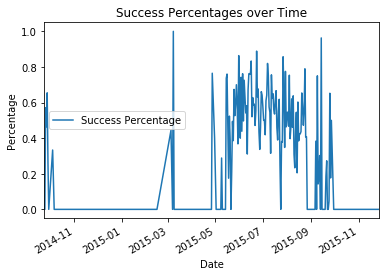

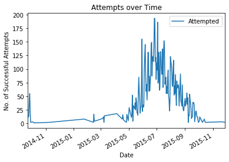

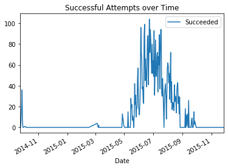

```python
agg = data.groupby("Date").sum().reset_index()
agg["Success Percentage"] = agg["Succeeded"]/agg["Attempted"]

ax = agg.plot(x="Date", y="Success Percentage", title="Success Percentages over Time")
ax.set_ylabel("Percentage")

ax = agg.plot(x="Date", y="Attempted", title="Attempts over Time")
ax.set_ylabel("No. of Attempts")

agg.plot(x="Date", y="Succeeded", title="Successful Attempts over Time")
ax.set_ylabel("No. of Successful Attempts")

plt.show()
```

### 1.2.2

*Plot all weather variables (except Wind Direction) over time in one diagram with two y-axes. The y-axis on the left of the diagram should contain data for Temperature and Wind Speed Daily, the y-axis on the right of the diagram should contain Relative Humidity and Solar Radiation. Plot the time-series in different colours and place a legend to the right of the diagram.*

To get a correct count over time, we need to keep only one instance of every date. So, first, we drop any duplicate Date. It doesn't matter which one we keep.

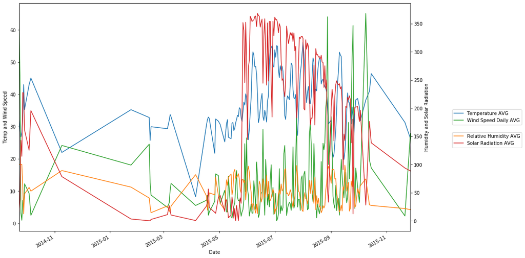

```python
conditions = data.drop_duplicates(subset=["Date"], keep="first")
conditions = conditions.drop(columns=["Route","Attempted","Succeeded","Success Percentage","Wind Direction AVG"])

ax = conditions.plot(x="Date", secondary_y=["Relative Humidity AVG", "Solar Radiation AVG"], figsize=(15,10))
ax.set_ylabel("Temp and Wind Speed")
ax.legend(loc='center left', bbox_to_anchor=(1.1, 0.5))
ax.right_ax.legend(loc='center left', bbox_to_anchor=(1.1, 0.4))
ax.right_ax.set_ylabel("Humidity and Solar Radiation")

plt.show()
```

### 1.2.3

*Plot all five weather variables as histograms (50 bins) in one diagram, assigning a different colour to each distribution. Specify two x-axes: the x-axis at the bottom should correspond to Temperature, Relative Humidity, and Wind Speed Daily (range from -5 to 100); the x-axis at the top should correspond to Wind Direction and Solar Radiation (range from 0 to 375)*

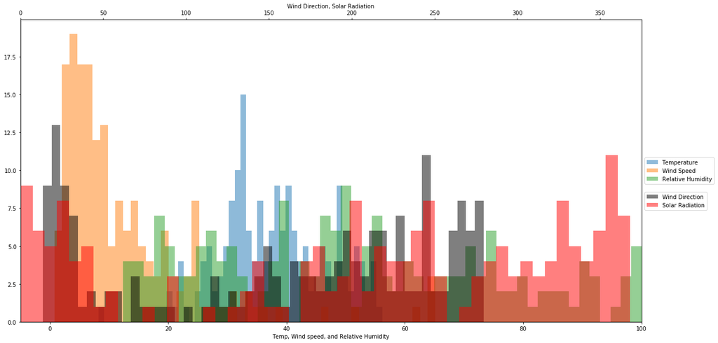

```python
conditions = data.drop_duplicates(subset=["Date"], keep="first")
w_vars = ["Temperature AVG", "Relative Humidity AVG", "Wind Speed Daily AVG", "Wind Direction AVG", "Solar Radiation AVG"]

fig = plt.figure(figsize=(20,10))
ax = fig.add_subplot(1,1,1)
ax.set_xlim(-5,100)
ax.hist(conditions["Temperature AVG"], label="Temperature", alpha=0.5, bins=50)
ax.hist(conditions["Wind Speed Daily AVG"], label="Wind Speed", alpha=0.5,bins=50)
ax.hist(conditions["Relative Humidity AVG"], label="Relative Humidity", alpha=0.5,bins=50)
ax.set_xlabel("Temp, Wind speed, and Relative Humidity")
ax.legend(loc='center left', bbox_to_anchor=(1.0, 0.5))

ax2 = ax.twiny()
ax2.set_xlim(0,375)
ax2.hist(conditions["Wind Direction AVG"], label="Wind Direction", alpha=0.5,bins=50, color="black")
ax2.hist(conditions["Solar Radiation AVG"], label="Solar Radiation", alpha=0.5,bins=50, color="red")
ax2.set_xlabel("Wind Direction, Solar Radiation")
ax2.legend(loc='center left', bbox_to_anchor=(1.0, 0.4))

plt.show()
```

## 1.3 Visualising Relationships Between Descriptors

*Write a function that shows 5x5 scatter plots of the five weather variables against each other. Comment on any observable relationships between variables and the possible impact on any regression task.*

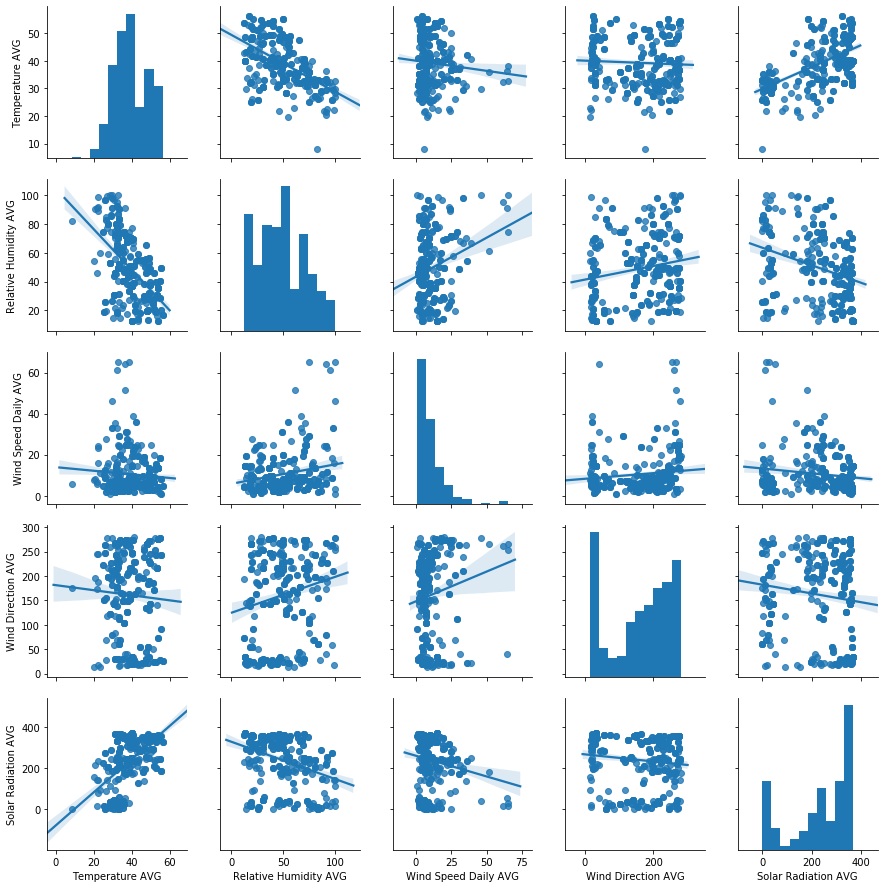

```python
import seaborn as sb
descriptors = ["Temperature AVG", "Relative Humidity AVG", "Wind Speed Daily AVG", "Wind Direction AVG", "Solar Radiation AVG"]
sb.pairplot(data[descriptors], kind="reg")
```

- See figures (1,2) and (2,1) - It seems like (apart from an outlying point at a very low temperature) there exists a correlation between temperature and humidity. For higher humidities, temperatures seem to be lower.
- (5,1) and (1,5) imply a correlation between Solar Radiation and Temperature.

Most of the other variables seem uncorrelated since most of the regression lines are quite flat, or have high uncertainties. The two correlations seen above (Temperature and humidity; temperature and solar radiation) don't seem strong enough to impact any regression we're going to do.

## 1.4 Splitting Training and Validation Sets

*Although in this coursework we will not use T-fold cross-validation in the standard form, it is important to know how to split the data into training and validation sets. Write a function that randomly divides the data set into a ‘training’ set with 80% of the rows, and a ‘validation’ set with the remaining 20%. Make sure that the training and validation sets have similar values for the Success Percentage.*

```python
#assume split of 20%
def split(X,y):
    X = X.copy()
    X["bin"] = pd.cut(X[y], 20)
    bins = [x for _, x in X.groupby("bin")]

    validation_set = pd.DataFrame()
    for b in bins:
        validation_set = validation_set.append(b.sample(frac=0.2))

    validation_set.drop("bin", axis=1, inplace=True)
    X.drop("bin", axis=1, inplace=True)
    X.drop(validation_set.index, axis=0, inplace=True)

    return X, validation_set

training_set, validation_set = split(data, "Success Percentage")
training_success_p = training_set.sum(axis=0)["Success Percentage"]/len(training_set)
val_success_p = validation_set.sum(axis=0)["Success Percentage"]/len(validation_set)
print("Training set mean success percentage: ", training_success_p)
print("Validation set mean success percentage: ", val_success_p)
```

```
Training set mean success percentage:  0.39987286429175567
Validation set mean success percentage:  0.3983024758254893
```

# 2 Comparing Regression and Classification Algorithms

## 2.1 Regression

### 2.1.1 Linear

*Using the cleaned and merged data prepared in Task 1, obtain a linear regression model to predict the ‘Success Percentage’ using the four weather features ‘Temperature’, ‘Relative Humidity’, ‘Wind Speed Daily’ and ‘Solar Radiation’ as predictors.*

*Report the parameters of the model and the in-sample error from the training set. Apply the model to the validation data to predict the ‘Success Percentage’ and compute the out-of-sample error from this vallidation set and compare with the in-sample error.*

*Test the model on out-of-sample data by predicting the ‘Success Percentage’ for the weather conditions from 28-31 December 2018 available as a CSV file on Blackboard (this is the test set).*

In the cell below, we train our model using the cleaned up data from part 1, and print the parameters:

```python
from sklearn.linear_model import LinearRegression
from sklearn.model_selection import train_test_split
from sklearn import metrics

attributes = ["Temperature AVG", "Relative Humidity AVG", "Wind Speed Daily AVG", "Solar Radiation AVG"]

X_train = training_set[attributes]
Y_train = training_set["Success Percentage"]

X_val = validation_set[attributes]
Y_val = validation_set["Success Percentage"]

lin_reg = LinearRegression()
lin_reg.fit(X_train, Y_train)

params = pd.DataFrame(lin_reg.coef_, X_train.columns, columns=['Coefficient'])
params
```

|  | Coefficient |
| --- | --- |
| Temperature AVG | -0.002278 |
| Relative Humidity AVG | 0.000273 |
| Wind Speed Daily AVG | -0.001801 |
| Solar Radiation AVG | 0.001400 |

Now, we look at sample errors for the training sample. I used the Mean Squared Error (MSE) and the Mean Absolute Error (MAE). MSE is useful because, by squaring the distances, it penalizes a model a lot more for making predictions that differ greatly from the actual expected value. In our case, climbing Moint Rainier, we could afford to be a few percents off but what we really want to avoid is to be very far off as that would become dangerous. Hence, the use of MSE.

MAE is more intuitive, calculating the average absolute distance between the predicted values and the actual values.

R-Squared score is a statistical measure of how close the data are fitted to the regression line; it's calculated as the model's explained variation over the total variation. Low scores (close to 0) mean that the model doesn't explain the variability in the set tested and that the model doesn't fit too well whereas high scores (close to 1) imply the model is a good fit for the data.

Everything is wrapped in a function as we're going to use it again in 2.1.2.

```python
def compute_errors(regressor, X_train, Y_train, X_val, Y_val):

    Y_train_pred = regressor.predict(X_train)
    training_error_mse = metrics.mean_squared_error(Y_train, Y_train_pred)
    training_error_mae = metrics.mean_absolute_error(Y_train, Y_train_pred)

    print("MSE for training set: ", training_error_mse)
    print("MAE for training set: ", training_error_mae)

    Y_val_pred = regressor.predict(X_val)
    validation_error_mse = metrics.mean_squared_error(Y_val, Y_val_pred)
    validation_error_mae = metrics.mean_absolute_error(Y_val, Y_val_pred)

    print("MSE for validation set: ", validation_error_mse)
    print("MAE for validation set: ", validation_error_mae)

    print("Difference between the in-sample MSE and out-of-sample MSE: ", abs(validation_error_mse - training_error_mse))
    print("Difference between the in-sample MAE and out-of-sample MAE: ", abs(validation_error_mae - training_error_mae))

    print("Model R Squared value: ", metrics.r2_score(Y_val, Y_val_pred))


compute_errors(lin_reg, X_train, Y_train, X_val, Y_val)
```

```
MSE for training set:  0.11705886306277032
MAE for training set:  0.28459620838669286
MSE for validation set:  0.1181001760710284
MAE for validation set:  0.28965497465176515
Difference between the in-sample MSE and out-of-sample MSE:  0.0010413130082580907
Difference between the in-sample MAE and out-of-sample MAE:  0.00505876626507229
Model R Squared value:  0.16396669418856036
```

We get an MAE of 0.28 meaning that on average the predictions are 28% off. This is very high and shows the model isn't a particularly good one. This is confirmed by the low R-Squared value of 0.16. An R2 value this low confirms the model doesn't fit the data well in most cases.

Nevertheless, We see that both the MSE and MAE are very close for both in-sample and out-of-sample. The errors are slightly larger in the out-of-sample case. This is expected as the model was fitted with the training set. Interestingly, the difference isn't massive- the MAEs are within a percent of each other.

Next, we try applying our model to the test set for the weather conditions from 28-31 December 2018. We can use the attributes to predict success percentages, and just add a column to the end of our dataframe:

```python
def predict_test_set(regressor):
    test_set = pd.read_csv("test_set.csv")
    X_test = test_set[test_set.columns[1:]]
    succ_pred = regressor.predict(X_test)
    test_set["Success Percentage"] = succ_pred
    return test_set

predict_test_set(lin_reg)
```

|  | Date | Temperature AVG | Relative Humidity AVG | Wind Speed Daily AVG | Solar Radiation AVG | Success Percentage |
| --- | --- | --- | --- | --- | --- | --- |
| 0 | 12/31/2018 | 24.062910 | 58.87083 | 17.977790 | 121.91529 | 0.260471 |
| 1 | 12/30/2018 | 44.631200 | 53.49383 | 13.540541 | 191.19283 | 0.317127 |
| 2 | 12/29/2018 | 22.614291 | 60.07291 | 10.451290 | 157.10091 | 0.326918 |
| 3 | 12/28/2018 | 31.687041 | 70.55791 | 9.876980 | 176.24120 | 0.336935 |

### 2.1.2 Ridge Regression

*Repeat the above task for Ridge Regression models. You will need to scan the penalty parameter of the Ridge models and establish the optimal value of the penalty for this dataset by examining the error on the validation set.*

*Explain your results using plots, code, and the effect of the parameter of in- sample and out-of-sample errors.*

First, we find the optimal value of the penalty parameter. I'll be looking in the range $ 10^{-15} $ to $ 1 $ logarithmically. This is because I expect the parameter to be quite low since the coefficients for the linear regression were small. Therefore, I want to look at closer intervals in the low values.

Then, we train a model with every alpha and find the alpha parameter that minimises MSE. The graph below plots values of alpha against their corresponding MSEs.

```
Alpha minimising MSE:  0.14891290324394058
```

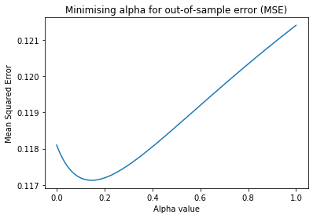

```python
from sklearn.linear_model import Ridge, RidgeCV

#Using the same training and validations sets

alphas = np.logspace(-15, 0, 400)
MSEs = []
ridge_reg = Ridge(normalize = True)

for a in alphas:
    ridge_reg.set_params(alpha = a)
    ridge_reg.fit(X_train, Y_train)
    Y_pred = ridge_reg.predict(X_val)
    mse = metrics.mean_squared_error(Y_val, Y_pred)
    MSEs.append(mse)

min_MSE_index = MSEs.index(min(MSEs))
min_alpha = alphas[min_MSE_index]
print("Alpha minimising MSE: ", min_alpha)

plt.plot(alphas, MSEs)
plt.title("Minimising alpha for out-of-sample error (MSE)")
plt.ylabel("Mean Squared Error")
plt.xlabel("Alpha value")
plt.show()
```

```python
ridge_reg.set_params(alpha = min_alpha)
ridge_reg.fit(X_train, Y_train)

compute_errors(ridge_reg, X_train, Y_train, X_val, Y_val)
params = pd.DataFrame(ridge_reg.coef_, X_train.columns, columns=['Coefficient'])
params
```

```
MSE for training set:  0.11774114831420493
MAE for training set:  0.29177417173296744
MSE for validation set:  0.11712741222081317
MAE for validation set:  0.29337671363010515
Difference between the in-sample MSE and out-of-sample MSE:  0.0006137360933917563
Difference between the in-sample MAE and out-of-sample MAE:  0.0016025418971377103
Model R Squared value:  0.17085290727075075
```

|  | Coefficient |
| --- | --- |
| Temperature AVG | -0.000082 |
| Relative Humidity AVG | 0.000224 |
| Wind Speed Daily AVG | -0.001858 |
| Solar Radiation AVG | 0.001138 |

We find very small coefficients, and a small alpha for the model. Obviously, that means the linear and ridge models are going to be very similar because the smaller the penalty parameter, the smaller the bias, and the closer to a linear model we get.

The errors are very similar to the linear regression's but slightly higher. Nevertheless, the R2 score is slightly higher, implying that the model is more fitted in general but lost some of the fit on the cases that used to match well.

```python
predict_test_set(ridge_reg)
```

|  | Date | Temperature AVG | Relative Humidity AVG | Wind Speed Daily AVG | Solar Radiation AVG | Success Percentage |
| --- | --- | --- | --- | --- | --- | --- |
| 0 | 12/31/2018 | 24.062910 | 58.87083 | 17.977790 | 121.91529 | 0.256448 |
| 1 | 12/30/2018 | 44.631200 | 53.49383 | 13.540541 | 191.19283 | 0.340675 |
| 2 | 12/29/2018 | 22.614291 | 60.07291 | 10.451290 | 157.10091 | 0.310876 |
| 3 | 12/28/2018 | 31.687041 | 70.55791 | 9.876980 | 176.24120 | 0.335334 |

## 2.2 Classification

### 2.2.1 Preparation of the data as categorical variables

*To solve the classification tasks you need to unfold your data so that each row contains a sucess variable that is binary, i.e., ‘success=1’ or ‘failure=0’ for each attempt. Use the functionalities in Python to create from the data provided an expanded table of climbs with date and weather descriptors as in the original table, but a binary outcome variable of success.*

To do this, we will iterate through rows, extracting how many attempts and successes were seen. We'll then create $success$ rows with a success=1 column and $ attempts - success$ with a success=0 column. Then, we append all these rows to a new dataframe. Finally, we can drop the "Attempted", "Succeeded", and "Success Percentage" columns:

```python
newset = pd.DataFrame()

for _, row in agg.iterrows():
    attempts = int(row["Attempted"])
    successes = int(row["Succeeded"])
    new_row = row.copy()

    new_row["Success"] = 1
    if successes > 0:
        newset = newset.append([new_row]*successes, ignore_index=True)

    new_row["Success"] = 0
    if (attempts-successes) > 0:
        newset = newset.append([new_row]*(attempts-successes), ignore_index=True)

newset.drop(["Attempted", "Succeeded", "Success Percentage"], axis=1, inplace=True)
newset
```

|  | Date | Temperature AVG | Relative Humidity AVG | Wind Speed Daily AVG | Wind Direction AVG | Solar Radiation AVG | Success |
| --- | --- | --- | --- | --- | --- | --- | --- |
| 0 | 2014-09-23 | 32.857333 | 100.000000 | 65.110667 | 254.273333 | 16.593800 | 0 |
| 1 | 2014-09-23 | 32.857333 | 100.000000 | 65.110667 | 254.273333 | 16.593800 | 0 |
| 2 | 2014-09-23 | 32.857333 | 100.000000 | 65.110667 | 254.273333 | 16.593800 | 0 |
| 3 | 2014-09-23 | 32.857333 | 100.000000 | 65.110667 | 254.273333 | 16.593800 | 0 |
| 4 | 2014-09-23 | 32.857333 | 100.000000 | 65.110667 | 254.273333 | 16.593800 | 0 |
| ... | ... | ... | ... | ... | ... | ... | ... |
| 9816 | 2015-11-21 | 31.300000 | 21.690708 | 2.245833 | 117.549667 | 93.660417 | 0 |
| 9817 | 2015-11-21 | 31.300000 | 21.690708 | 2.245833 | 117.549667 | 93.660417 | 0 |
| 9818 | 2015-11-21 | 31.300000 | 21.690708 | 2.245833 | 117.549667 | 93.660417 | 0 |
| 9819 | 2015-11-27 | 26.321667 | 19.715000 | 27.839583 | 68.004167 | 88.496250 | 0 |
| 9820 | 2015-11-27 | 26.321667 | 19.715000 | 27.839583 | 68.004167 | 88.496250 | 0 |

9821 rows × 7 columns

### 2.2.2 Logistic regression (10 marks)

*Train a logistic regression classifier on the training data with the same four weather conditions as features and the binary success of summiting Mount Rainier as the output. After the classifier is trained, estimate the probability to successfully summit on the validation data. Compare the errors in the training data and validation data using different metrics.*

```python
from sklearn.linear_model import LogisticRegression

attributes = ["Temperature AVG", "Relative Humidity AVG", "Wind Speed Daily AVG", "Solar Radiation AVG"]
training_set, validation_set = split(newset, "Success")

X_train = training_set[attributes]
Y_train = training_set["Success"]

X_val = validation_set[attributes]
Y_val = validation_set["Success"]

logreg = LogisticRegression(solver="lbfgs")
logreg.fit(X_train, Y_train)

preds= logreg.predict(X_val)
prob_success = np.count_nonzero(preds==1)/len(preds)
print("The probability to successfully summit Mt. Rainier: ", prob_success)
```

```
The probability to successfully summit Mt. Rainier:  0.4175152749490835
```

```python
from sklearn.metrics import confusion_matrix, classification_report

print(classification_report(Y_val, logreg.predict(X_val)))
```

```
              precision    recall  f1-score   support

           0       0.59      0.68      0.63      1001
           1       0.60      0.52      0.56       963

    accuracy                           0.60      1964
   macro avg       0.60      0.60      0.59      1964
weighted avg       0.60      0.60      0.59      1964
```

The three standard metrics to use in classifiers are precision, recall, and F1. They allow to for a more detailed analysis than just accuracy which can give an uncomplete picture of the model.

Here, we'll deal with True Positives (TP), False Positives (FP), False Negatives (FN), and True Negatives (TN)

$Precision = \frac{TP}{TP+FP} = $ truly successful attempts given it was classified as successful

$Recall = \frac{TP}{TP+FN} = $ the ability to identify successful attempts

$F1 = 2*\frac{Precision * Recall}{Precision + Recall} = $ the harmonic mean of both precision and recall

F1 is a useful measure because it takes into account both measures and penalises extreme values (by taking the harmonic mean instead of a simple average). Now, to analyze our results.

First, we see that the two classes (0, and 1) are well balanced in the validation set, differing in size by 38 samples. None of our precision and recall scores are high. Our precision average to 60%. For the case success=1, 40% of the time our classifier tells us we could summit Mt. Rainier we couldn't. This is an important metric as climbing the mountain could be dangerous and pushing climbers to go out in dangerous conditions is to avoid at all costs. Our recall is low as well, averaging at 60% again. This means we're missing a lot of good climbing days. It's a shame but it's less important than the precision metric in our situation as this would not put anyone in danger.

At this point, the F1 tells us what we already know - we've got a middling model that works barely above half the time. Below, we predict Success chances for the test set.

```python
test_set = pd.read_csv("test_set.csv")
X_test = test_set[test_set.columns[1:]]
succ_pred = logreg.predict(X_test)
test_set["Success"] = succ_pred
test_set
```

|  | Date | Temperature AVG | Relative Humidity AVG | Wind Speed Daily AVG | Solar Radiation AVG | Success |
| --- | --- | --- | --- | --- | --- | --- |
| 0 | 12/31/2018 | 24.062910 | 58.87083 | 17.977790 | 121.91529 | 0 |
| 1 | 12/30/2018 | 44.631200 | 53.49383 | 13.540541 | 191.19283 | 0 |
| 2 | 12/29/2018 | 22.614291 | 60.07291 | 10.451290 | 157.10091 | 0 |
| 3 | 12/28/2018 | 31.687041 | 70.55791 | 9.876980 | 176.24120 | 0 |

### 2.2.3 Naive Bayes (10 marks)

*Same as for the logistic regression classifier in 2.2.2, but training a Naive Bayes classifier on the training data with the same four weather conditions as features and the binary success of summiting Mount Rainier as the output. After the classifier is trained, estimate the probability of summiting on the validation data. Compare and discuss the errors in the training data and validation data.*

```python
from sklearn.naive_bayes import GaussianNB

gnb = GaussianNB()
gnb.fit(X_train, Y_train)

preds= gnb.predict(X_val)
print(classification_report(Y_val, preds))

prob_success = np.count_nonzero(preds==1)/len(preds)
print("The probability to successfully summit Mt. Rainier: ", prob_success)
```

```
              precision    recall  f1-score   support

           0       0.56      0.66      0.60      1001
           1       0.56      0.45      0.50       963

    accuracy                           0.56      1964
   macro avg       0.56      0.56      0.55      1964
weighted avg       0.56      0.56      0.55      1964

The probability to successfully summit Mt. Rainier:  0.3966395112016293
```

On every account, our values for the Gaussian Naive Bays (GNB) classifier are slightly lower than they were for our logistic regression classifier. Therefore, the same comments apply.

Overall, it looks like a Naive Bayes classifier is not as good choice as the logistic regression classifier for this task.

```python
from scipy import stats
new_training_set = training_set.drop(["Date"], axis=1)
new_training_set = new_training_set[(np.abs(stats.zscore(new_training_set)) < 3).all(axis=1)]

new_X_train = new_training_set[attributes]
new_Y_train = new_training_set["Success"]

gnb = GaussianNB()
gnb.fit(new_X_train, new_Y_train)

preds= gnb.predict(X_val)
print(classification_report(Y_val, preds))

prob_success = np.count_nonzero(preds==1)/len(preds)
print("The probability to successfully summit Mt. Rainier: ", prob_success)
```

```
              precision    recall  f1-score   support

           0       0.57      0.62      0.60      1001
           1       0.57      0.53      0.55       963

    accuracy                           0.57      1964
   macro avg       0.57      0.57      0.57      1964
weighted avg       0.57      0.57      0.57      1964

The probability to successfully summit Mt. Rainier:  0.4526476578411405
```